# SC-Project

2022-06-07

## 1.Data

### **Diabetes Dataset**

**Context**

> This dataset is originally from the National Institute of Diabetes and Digestive and Kidney Diseases. The objective is to predict based on diagnostic measurements whether a patient has diabetes. Link: https://www.kaggle.com/datasets/mathchi/diabetes-data-set

**Content**

> Several constraints were placed on the selection of these instances from a larger database. In particular, all patients here are females at least 21 years old of Pima Indian heritage.
- Pregnancies: Number of times pregnant
- Glucose: Plasma glucose concentration a 2 hours in an oral glucose tolerance test
- BloodPressure: Diastolic blood pressure (mm Hg)
- SkinThickness: Triceps skin fold thickness (mm)
- Insulin: 2-Hour serum insulin (mu U/ml)
- BMI: Body mass index (weight in kg/(height in m)^2)
- DiabetesPedigreeFunction: Diabetes pedigree function
- Age: Age (years)
- Outcome: Class variable (0 or 1)

Several constraints were placed on the selection of these instances from a larger database. In particular, all patients here are females at least 21 years old of Pima Indian heritage.

**Details**

> Number of Instances: 768 | Number of Attributes: 8 plus class | For Each Attribute: (all numeric-valued)
- Number of times pregnant
- Plasma glucose concentration a 2 hours in an oral glucose tolerance test
- Diastolic blood pressure (mm Hg)
- Triceps skin fold thickness (mm)
- 2-Hour serum insulin (mu U/ml): (mu Uracil/ml)
- Body mass index (weight in kg/(height in m)^2)
- Diabetes pedigree function
- Age (years)
- Class variable (0 or 1)

Missing Attribute Values: Yes

```r
library(readr)
library(stats)
library(tidyverse)
#import your .csv file to your Global Environment
diabetes_dataset <- read.csv("diabetes.csv", header = TRUE, sep= ",") #.csv as df
head(diabetes_dataset)
```

```
##   Pregnancies Glucose BloodPressure SkinThickness Insulin  BMI
## 1           6     148            72            35       0 33.6
## 2           1      85            66            29       0 26.6
## 3           8     183            64             0       0 23.3
## 4           1      89            66            23      94 28.1
## 5           0     137            40            35     168 43.1
## 6           5     116            74             0       0 25.6
##   DiabetesPedigreeFunction Age Outcome
## 1                    0.627  50       1
## 2                    0.351  31       0
## 3                    0.672  32       1
## 4                    0.167  21       0
## 5                    2.288  33       1
## 6                    0.201  30       0
```

```r
#adding ID column
diabetes_dataset <- tibble::rowid_to_column(diabetes_dataset, "ID")
```

## 2.Exploratory and descriptive data analysis:

Including ID column, 8 of them are integer and 2 of them are numeric variables.

Here’s a summary of the variables:

| name | variable type |
| --- | --- |
| Pregnancies | numerical, quantitative, discrete |
| Glucose | numerical, quantitative, discrete |
| BloodPressure | numerical, quantitative, continuous |
| SkinThickness | numerical, quantitative, discrete |
| Insulin | numerical, quantitative, discrete |
| BMI | numerical, quantitative, continuous |
| DiabetesPedigreeFunction | numerical, quantitative, continuous |
| Age | numerical, quantitative, continuous |
| Outcome | numerical - int |

```r
str(diabetes_dataset)
```

```
## 'data.frame':    768 obs. of  10 variables:
##  $ ID                      : int  1 2 3 4 5 6 7 8 9 10 ...
##  $ Pregnancies             : int  6 1 8 1 0 5 3 10 2 8 ...
##  $ Glucose                 : int  148 85 183 89 137 116 78 115 197 125 ...
##  $ BloodPressure           : int  72 66 64 66 40 74 50 0 70 96 ...
##  $ SkinThickness           : int  35 29 0 23 35 0 32 0 45 0 ...
##  $ Insulin                 : int  0 0 0 94 168 0 88 0 543 0 ...
##  $ BMI                     : num  33.6 26.6 23.3 28.1 43.1 25.6 31 35.3 30.5 0 ...
##  $ DiabetesPedigreeFunction: num  0.627 0.351 0.672 0.167 2.288 ...
##  $ Age                     : int  50 31 32 21 33 30 26 29 53 54 ...
##  $ Outcome                 : int  1 0 1 0 1 0 1 0 1 1 ...
```

```r
diabetes_dataset %>% count(Outcome)
```

```
##   Outcome   n
## 1       0 500
## 2       1 268
```

## 3.Data Visualization:

### Converting numerical data to cathegorical:

Need to define how we want to parse the data into buckets. The first decision is to decide the number of buckets. The second decision is to decide how to allocate the data into the buckets.

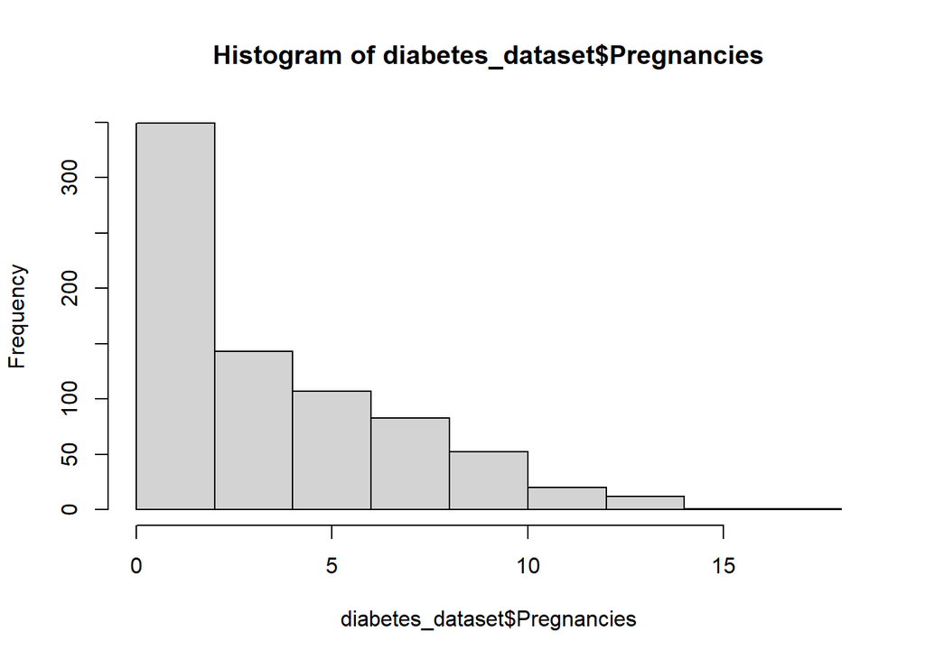

```r
#First looking at the variable that going to be arrange as cathegorical in histogram and summary of it

hist(diabetes_dataset$Pregnancies)
```

```r
summary(diabetes_dataset$Pregnancies)
```

```
##    Min. 1st Qu.  Median    Mean 3rd Qu.    Max.
##   0.000   1.000   3.000   3.845   6.000  17.000
```

```r
#define the new categorical variables : Pregnancies.cat and Outcome.cat
diabetes_dataset <- within(diabetes_dataset, {
  Pregnancies.cat <- NA # need to initialize variable
  Pregnancies.cat[Pregnancies < 2] <- "Low"
  Pregnancies.cat[Pregnancies >= 2 & Pregnancies < 4] <- "Normal"
  Pregnancies.cat[Pregnancies >= 4] <- "High"
   } )

diabetes_dataset <- within(diabetes_dataset, {
  Outcome.cat <- NA # need to initialize variable
  Outcome.cat[Outcome == 1] <- "1"
  Outcome.cat[Outcome == 0] <- "0"
   } )

#for two hour after the glucose tolerance test, blood glucose level is lower than 155 mg/dL-decilitre
diabetes_dataset <- within(diabetes_dataset, {
  Glucose.cat <- NA # need to initialize variable
  Glucose.cat[Glucose < 155] <- "1" #normal
  Glucose.cat[Glucose >= 155] <- "0" #abnormal
   } )
```

```r
#The converting to the factor variable

diabetes_dataset$Pregnancies.cat <- factor(diabetes_dataset$Pregnancies.cat, levels = c("High", "Normal", "Low"))
diabetes_dataset$Outcome.cat <- factor(diabetes_dataset$Outcome.cat, levels = c("1", "0"))
diabetes_dataset$Glucose.cat <- factor(diabetes_dataset$Outcome.cat, levels = c("1", "0"))

str(diabetes_dataset)
```

```
## 'data.frame':    768 obs. of  13 variables:
##  $ ID                      : int  1 2 3 4 5 6 7 8 9 10 ...
##  $ Pregnancies             : int  6 1 8 1 0 5 3 10 2 8 ...
##  $ Glucose                 : int  148 85 183 89 137 116 78 115 197 125 ...
##  $ BloodPressure           : int  72 66 64 66 40 74 50 0 70 96 ...
##  $ SkinThickness           : int  35 29 0 23 35 0 32 0 45 0 ...
##  $ Insulin                 : int  0 0 0 94 168 0 88 0 543 0 ...
##  $ BMI                     : num  33.6 26.6 23.3 28.1 43.1 25.6 31 35.3 30.5 0 ...
##  $ DiabetesPedigreeFunction: num  0.627 0.351 0.672 0.167 2.288 ...
##  $ Age                     : int  50 31 32 21 33 30 26 29 53 54 ...
##  $ Outcome                 : int  1 0 1 0 1 0 1 0 1 1 ...
##  $ Pregnancies.cat         : Factor w/ 3 levels "High","Normal",..: 1 3 1 3 3 1 2 1 2 1 ...
##  $ Outcome.cat             : Factor w/ 2 levels "1","0": 1 2 1 2 1 2 1 2 1 1 ...
##  $ Glucose.cat             : Factor w/ 2 levels "1","0": 1 2 1 2 1 2 1 2 1 1 ...
```

```r
library(lessR)
```

```
## [Trellis graphics from Deepayan Sarkar's lattice package]
```

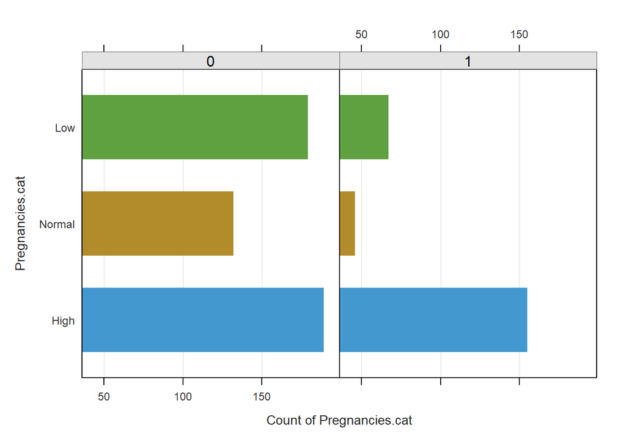

```
## Joint and Marginal Frequencies
## ------------------------------
##
## Pregnancies.cat
## Outcome   High Normal Low Sum
##   0        189    132 179 500
##   1        155     46  67 268
##   Sum      344    178 246 768
##
## Cramer's V: 0.192
##
## Chi-square Test:  Chisq = 28.412, df = 2, p-value = 0.000
```

```r
#Barchart visualization with pregnancies by outcome
BarChart(Pregnancies.cat, data=diabetes_dataset, by1 = Outcome) #Pregnancies by outcome
```

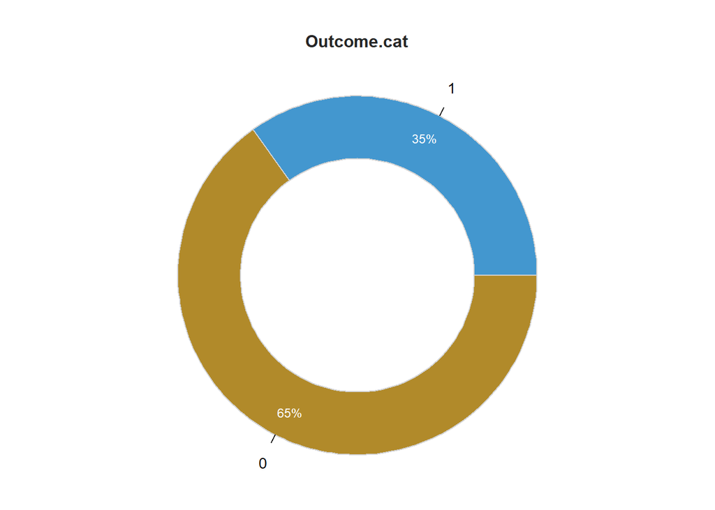

```
## >>> Suggestions
## PieChart(Outcome.cat, hole=0)  # traditional pie chart
## PieChart(Outcome.cat, values="%")  # display %'s on the chart
## PieChart(Outcome.cat)  # bar chart
## Plot(Outcome.cat)  # bubble plot
## Plot(Outcome.cat, values="count")  # lollipop plot
##
## --- Outcome.cat ---
##
##                    1      0     Total
## Frequencies:     268    500       768
## Proportions:   0.349  0.651     1.000
##
## Chi-squared test of null hypothesis of equal probabilities
##   Chisq = 70.083, df = 1, p-value = 0.000
```

```r
#PieChart with Outcome categorical
PieChart(Outcome.cat, data= diabetes_dataset)
```

- In LessR Plot is a general function which includes violin plot, box plot and scatter plot (which are individual cases beyond the whiskers, they might be outliers). Also we can see the mean, median, sd and outlier outcomes. The graph looks skewed right data distribution.

```
## [Trellis graphics from Deepayan Sarkar's lattice package]
## >>> Suggestions
## Plot(DiabetesPedigreeFunction, out_cut=2, fences=TRUE, vbs_mean=TRUE)  # Label two outliers ...
## Plot(DiabetesPedigreeFunction, box_adj=TRUE)  # Adjust boxplot whiskers for asymmetry
## ttest(DiabetesPedigreeFunction ~ Outcome.cat)  # Add the data parameter if not the d data frame
```

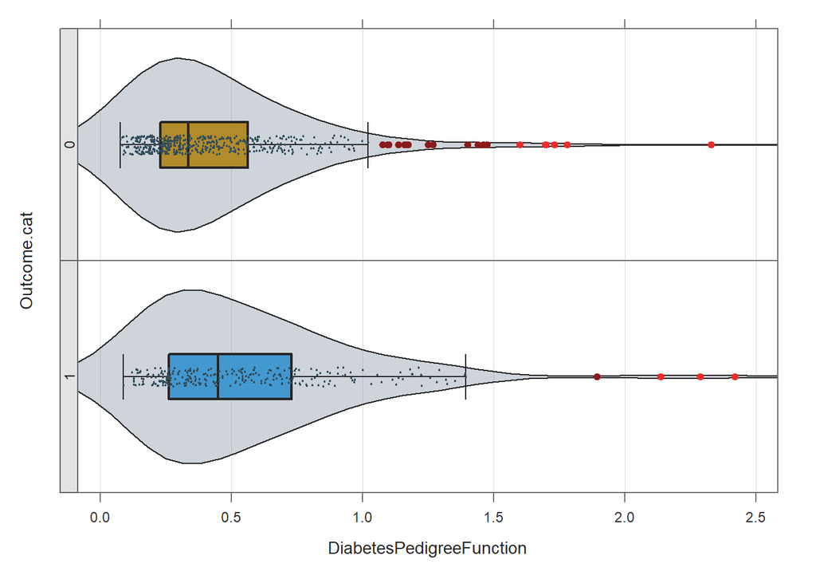

```
## DiabetesPedigreeFunction
##   - by levels of -
## Outcome.cat
##
##        n   miss       mean         sd        min        mdn        max
## 1   268      0     0.5505     0.3724     0.0880     0.4490     2.4200
## 0   500      0     0.4297     0.2991     0.0780     0.3360     2.3290
##
##        Max Dupli-
## Level   cations   Values
## ------------------------------
## 1           4     0.254
## 0           5     0.207
##
## Parameter values (can be manually set)
## -------------------------------------------------------
## size: 0.21      size of plotted points
## out_size: 0.66  size of plotted outlier points
## jitter_y: 2.42 random vertical movement of points
## jitter_x: 0.00  random horizontal movement of points
## bw: 0.18       set bandwidth higher for smoother edges
```

```r
#continuous variable: interval or ratio measurement scales
Plot(DiabetesPedigreeFunction, data= diabetes_dataset, by1 = Outcome.cat)
```

## 4.Central Limit Theorem:

- As we plot the frequency distribution of skin thickness, we can see that it is not normally distributed.

```r
summary(diabetes_dataset$SkinThickness)
```

```
##    Min. 1st Qu.  Median    Mean 3rd Qu.    Max.
##    0.00    0.00   23.00   20.54   32.00   99.00
```

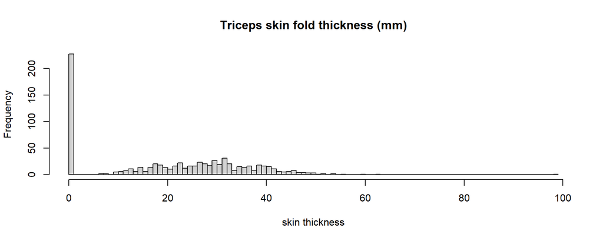

```r
par(mfrow=c(1, 1))
num_breaks = seq(0.00, max(diabetes_dataset$SkinThickness))
hist(diabetes_dataset$SkinThickness, breaks = num_breaks, main = "Triceps skin fold thickness (mm)", xlab = "skin thickness")
```

- According to the Central Limit Theorem, when repeatedly take samples from this distribution then the frequency distribution of the sample means will be normally distributed.
- The plot.sample.means() function will draw samples of sample_size from the dataset 1000 times, calculate the means and plot the distribution.

```r
plot.sample.mean <- function(dataset, sample_size) {
  samples <- replicate(1000, sample(dataset, sample_size))
  sample_mean <- apply(samples, 2, mean)
  hist(sample_mean, breaks = max(dataset), main = paste("Sample Size = ", sample_size), xlab = "Mean")
}
```

- The seed can be any integer value and it doesn’t matter what the value is, as long as it remains contant. Initializing the seed ensures that two different computers using the same seed will get identical samples from the random number generator.

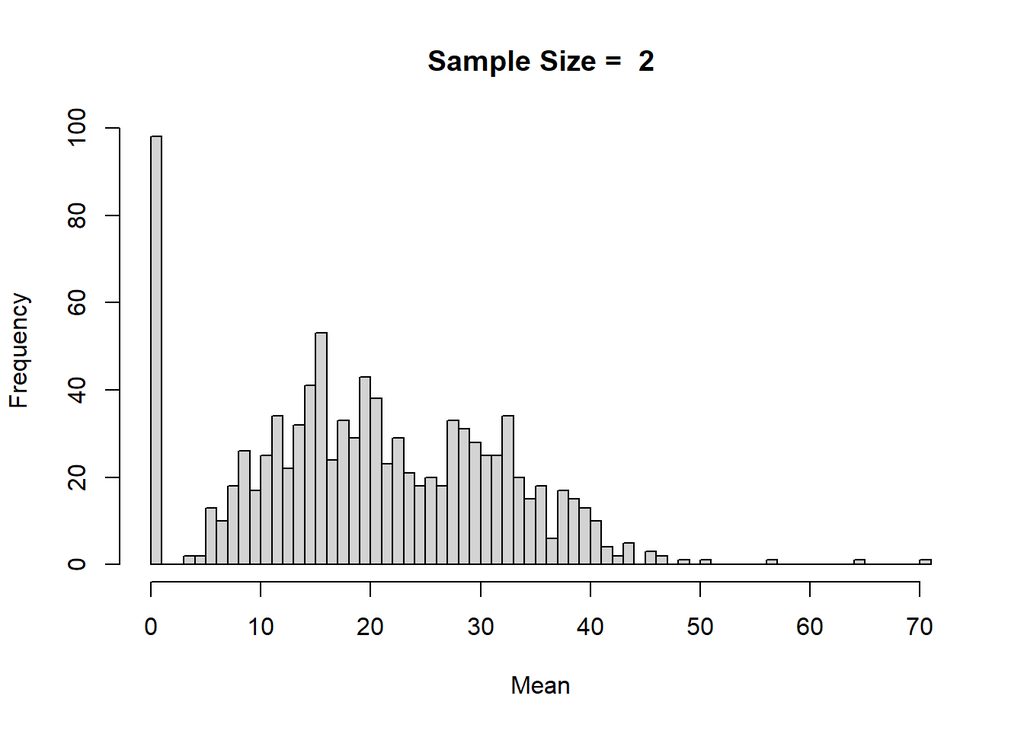

```r
set.seed(12345)
plot.sample.mean(diabetes_dataset$SkinThickness, sample_size = 2)
```

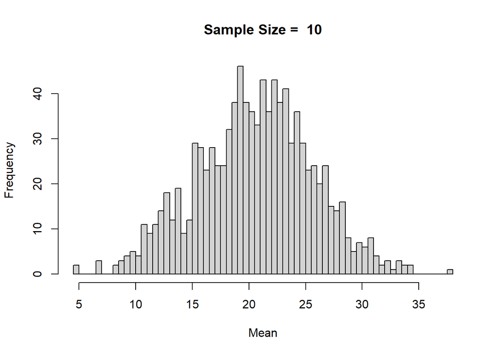

```r
plot.sample.mean(diabetes_dataset$SkinThickness, sample_size = 10)
```

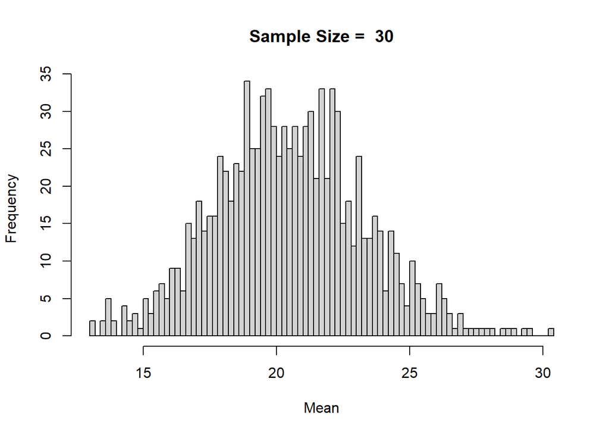

```r
plot.sample.mean(diabetes_dataset$SkinThickness, sample_size = 30)
```

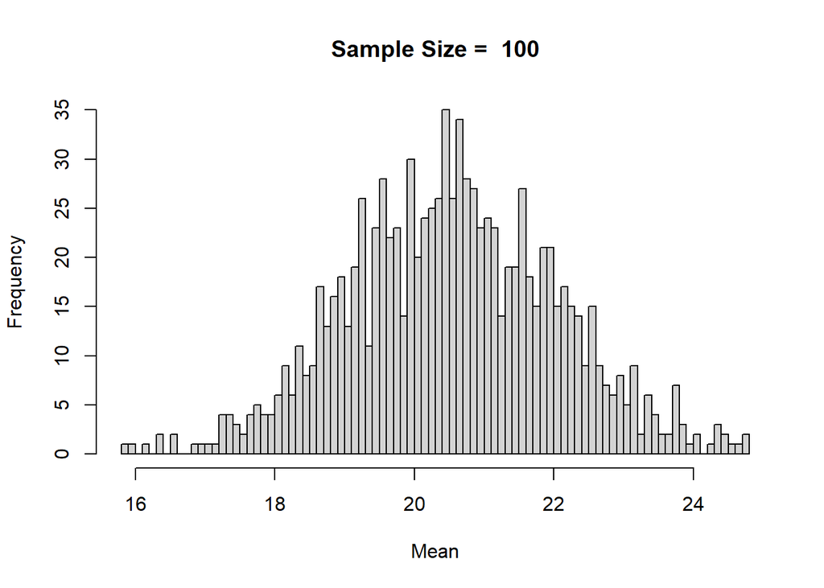

```r
plot.sample.mean(diabetes_dataset$SkinThickness, sample_size = 100)
```

- The distribution becomes closer and closer to being normally distributed as the sample size increases.

## 5.Confidence Intervals:

- A confidence interval is the mean of your estimate plus and minus the variation in that estimate.

### a. Calculating a Confidence Interval From a Normal Distribution

```r
library(skimr)
skim(diabetes_dataset$SkinThickness)
```

Data summary

| Name | diabetes_dataset$SkinThic… |
| --- | --- |
| Number of rows | 768 |
| Number of columns | 1 |
| _______________________ |  |
| Column type frequency: |  |
| numeric | 1 |
| ________________________ |  |
| Group variables | None |

**Variable type: numeric**

| skim_variable | n_missing | complete_rate | mean | sd | p0 | p25 | p50 | p75 | p100 | hist |
| --- | --- | --- | --- | --- | --- | --- | --- | --- | --- | --- |
| data | 0 | 1 | 20.54 | 15.95 | 0 | 0 | 23 | 32 | 99 | ▇▇▂▁▁ |

```r
total_num_data <-length(diabetes_dataset$SkinThickness)
mean <-mean(diabetes_dataset$SkinThickness)
sd <- sd(diabetes_dataset$SkinThickness)

#95% confidence level used and wish to find the confidence interval.

error_a <- qnorm(0.975)*sd/sqrt(total_num_data)
left_a <- mean-error_a
right_a <- mean+error_a

cat("Width of confidence interval\nlower confidence limit: ",left_a,"\nupper catonfidence limit: ",right_a)
```

```
## Width of confidence interval
## lower confidence limit:  19.40825
## upper catonfidence limit:  21.66466
```

### b. Calculating a Confidence Interval From a t-distribution

```r
#95% confidence level used and wish to find the confidence interval.
error_b <- qt(0.975, df= total_num_data-1)*sd/sqrt(total_num_data)
left_b <- mean - error_b
right_b <- mean + error_b

cat("Width of confidence interval\nlower confidence limit: ",left_b,"\nupper catonfidence limit: ",right_b)
```

```
## Width of confidence interval
## lower confidence limit:  19.40647
## upper catonfidence limit:  21.66645
```

## 6.Transformation:

As we see here Age column not normally distributed. It seems it is right skewed distribution.

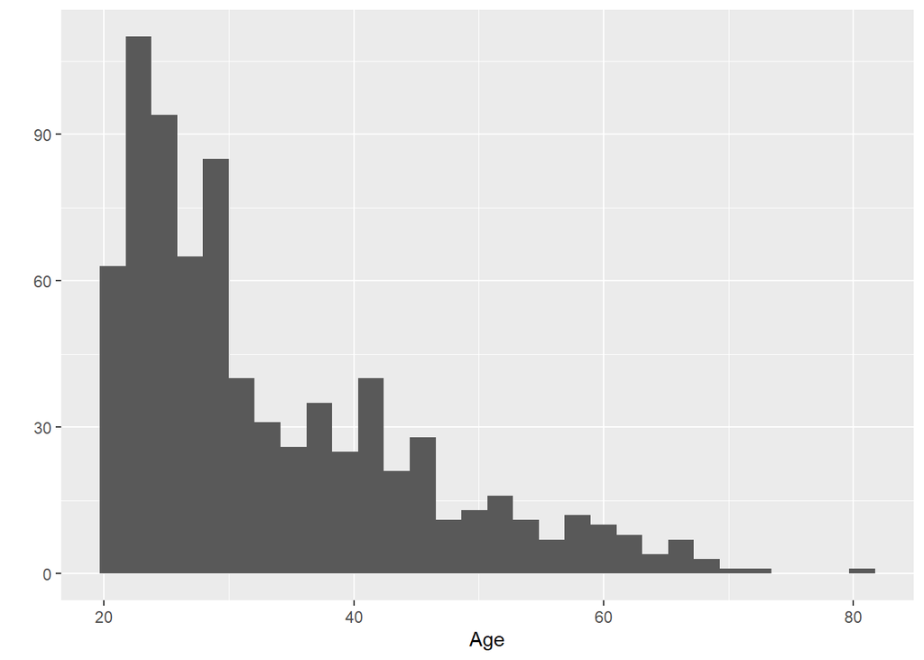

```r
#first looking raw data qplot and summary of Age column
qplot(x= Age, data = diabetes_dataset)
```

```r
summary(diabetes_dataset$Age)
```

```
##    Min. 1st Qu.  Median    Mean 3rd Qu.    Max.
##   21.00   24.00   29.00   33.24   41.00   81.00
```

```r
#then looking summary of the log10 function for Age column
summary(log10(diabetes_dataset$Age))
```

```
##    Min. 1st Qu.  Median    Mean 3rd Qu.    Max.
##   1.322   1.380   1.462   1.498   1.613   1.908
```

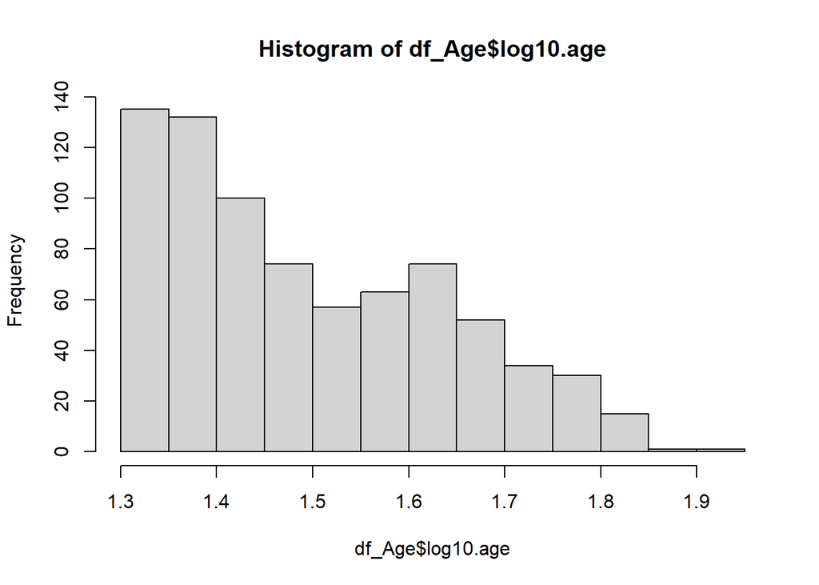

```r
#log transformation
df_Age <- data.frame(log10.age = log10(diabetes_dataset$Age))
par(mfrow=c(1,1))
hist(df_Age$log10.age)
```

## 7.Single t-test (Wilcoxon t-test):

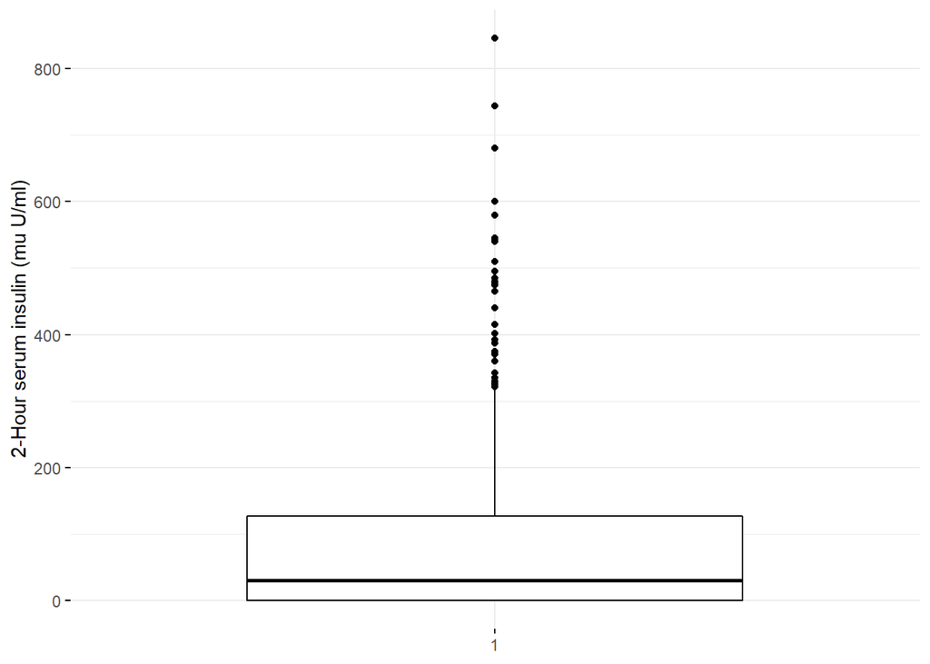

```r
library(ggpubr)
#data visualization
ggboxplot(diabetes_dataset$Insulin,
          ylab= "2-Hour serum insulin (mu U/ml)", xlab=FALSE,
          ggtheme = theme_minimal())
```

```r
skim(diabetes_dataset$Insulin)
```

Data summary

| Name | diabetes_dataset$Insulin |
| --- | --- |
| Number of rows | 768 |
| Number of columns | 1 |
| _______________________ |  |
| Column type frequency: |  |
| numeric | 1 |
| ________________________ |  |
| Group variables | None |

**Variable type: numeric**

| skim_variable | n_missing | complete_rate | mean | sd | p0 | p25 | p50 | p75 | p100 | hist |
| --- | --- | --- | --- | --- | --- | --- | --- | --- | --- | --- |
| data | 0 | 1 | 79.8 | 115.24 | 0 | 0 | 30.5 | 127.25 | 846 | ▇▁▁▁▁ |

#### a) Aim:

- The main aim in this test is the whether the median (m) of the sample is less than to the theoretical value (m0).

#### c) Assumption Check:

- Assumption 1: Samples are independent
- Assumption 2: Samples do not need to be drawn from a population with a normal distribution

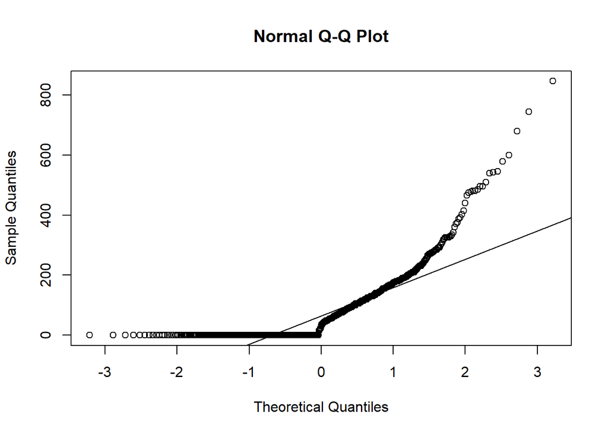

```r
#visualizing if it is normally distributed
qqnorm(diabetes_dataset$Insulin)
qqline(diabetes_dataset$Insulin)
```

#### d) Indicate “which test you choose” “for what reason”:

- I choose wilcoxon test to determine whether the median of the sample is equal to a known standard value (i.e. theoretical value).
- I want to know, if the median value of 2-hour serum insulin less than to the 35 U/ml (one-tailed test)?

```r
#computing one-sample Wilcoxon test
res <- wilcox.test(diabetes_dataset$Insulin, mu=35, alternative= "less")
res
```

```
##
##  Wilcoxon signed rank test with continuity correction
##
## data:  diabetes_dataset$Insulin
## V = 194738, p-value = 1
## alternative hypothesis: true location is less than 35
```

#### e) Result:

```r
# print only the p-value
res$p.value
```

```
## [1] 1
```

- The p-value of the test is 1, which is greater than the significance level alpha = 0.05.

#### g) What can be Type-1 and Type-2 error here?:

- Decision: Do not reject H0
- Actual situation:
  - H0 True: No Error, probability 1-alpha
  - H0 False: Type 2 Error, probability beta

## 8. Paired t-test:

#### a) Aim:

```r
#import your .csv file to your Global Environment
bloodpressure_dataset <- read.csv("BloodPressure.csv", header = TRUE, sep= ",") #.csv as df
attach(bloodpressure_dataset)
names(bloodpressure_dataset)
```

```
## [1] "Subject" "Before"  "After"
```

```r
head(bloodpressure_dataset)
```

```
##   Subject Before After
## 1       1    135   127
## 2       2    142   145
## 3       3    137   131
## 4       4    122   125
## 5       5    147   132
## 6       6    151   147
```

#### b) Hypothesis and level of significance:

```r
#summary of dataset
skim(bloodpressure_dataset)
```

Data summary

| Name | bloodpressure_dataset |
| --- | --- |
| Number of rows | 25 |
| Number of columns | 3 |
| _______________________ |  |
| Column type frequency: |  |
| numeric | 3 |
| ________________________ |  |
| Group variables | None |

**Variable type: numeric**

| skim_variable | n_missing | complete_rate | mean | sd | p0 | p25 | p50 | p75 | p100 | hist |
| --- | --- | --- | --- | --- | --- | --- | --- | --- | --- | --- |
| Subject | 0 | 1 | 13.00 | 7.36 | 1 | 7 | 13 | 19 | 25 | ▇▇▇▇▇ |
| Before | 0 | 1 | 138.28 | 11.70 | 117 | 131 | 137 | 147 | 158 | ▇▅▇▇▇ |
| After | 0 | 1 | 130.28 | 7.96 | 119 | 125 | 130 | 135 | 147 | ▅▇▆▃▃ |

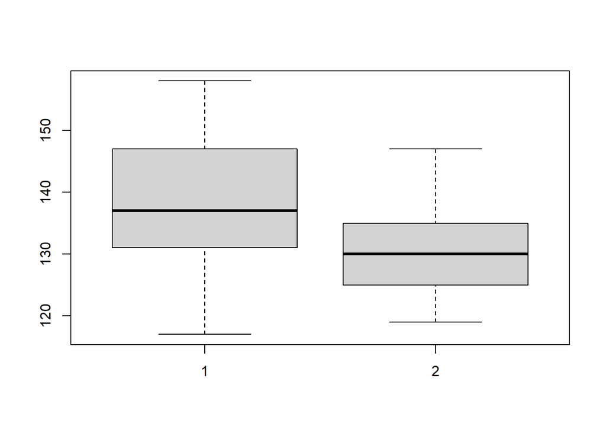

```r
#visualizing dataset
boxplot(bloodpressure_dataset$Before, bloodpressure_dataset$After)
```

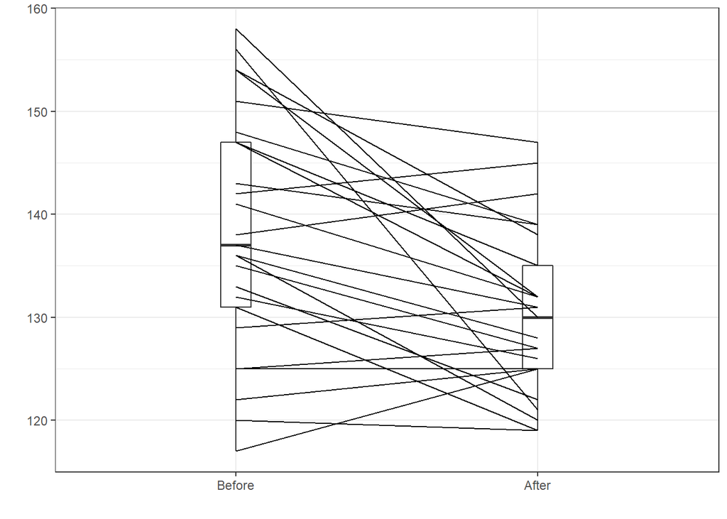

```r
# Plot paired data
library(PairedData)
pd <- paired(Before, After)
plot(pd, type = "profile") + theme_bw()
```

#### c) Assumption Check:

- Are the two samples paired? : Yes, since the data have been collected from measuring twice the blood pressure of the same patients.
- Is this a large sample? : No, because n < 30. Since the sample size is not large enough (less than 30), we need to check whether the differences of the pairs follow a normal distribution.
- How to check the normality? : Shapiro-Wilk normality test as described at:
  - Null hypothesis: the data are normally distributed
  - Alternative hypothesis: the data are not normally distributed

```r
# compute the difference
d <- After - Before
# Shapiro-Wilk normality test for the differences
shapiro.test(d)
```

```
##
##  Shapiro-Wilk normality test
##
## data:  d
## W = 0.94679, p-value = 0.212
```

- From the output, the p-value is greater than the significance level 0.05 implying that the distribution of the differences (d) are not significantly different from normal distribution. In other words, we can assume the normality.

```r
#paired samples t-test
t.test(Before, After, mu=0, alt="two.sided", paired = T, conf.level = 0.95)
```

```
##
##  Paired t-test
##
## data:  Before and After
## t = 3.8882, df = 24, p-value = 0.0006986
## alternative hypothesis: true mean difference is not equal to 0
## 95 percent confidence interval:
##   3.753515 12.246485
## sample estimates:
## mean difference
##               8
```

#### d) Result:

- The p-value of the test is 0.0006986, which is less than the significance level alpha = 0.05.

#### e) Conclusion:

- Because of p-value and after looking at the alternative hypothesis result, we can then reject null hypothesis and conclude that the average blood pressure of the patients before treatment is significantly different from the average blood pressure after treatment.

## 9. Fisher’s exact test for count data:

#### a) Aim:

- Aim is looking at Glucose tolerances broken down by Outcome status. We can think of it as another approach to the t-test problem, this time looking at indicators of glucose tolerances instead of the actual glucose tolerance amounts.

#### b) Hypothesis and level of significance:

- Determine whether there is a statistically significant association between glucose tolerance amount and diabetes outcome.
- H0: the variables are independent, there is no relationship between the two categorical variables. Knowing the value of one variable does not help to predict the value of the other variable
- H1: the variables are dependent, there is a relationship between the two categorical variables. Knowing the value of one variable helps to predict the value of the other variable

```r
#summarized in the contingency table
glucose.outcome.tbl <- with(diabetes_dataset, table(Glucose.cat, Outcome.cat))
glucose.outcome.tbl
```

```
##            Outcome.cat
## Glucose.cat   1   0
##           1 268   0
##           0   0 500
```

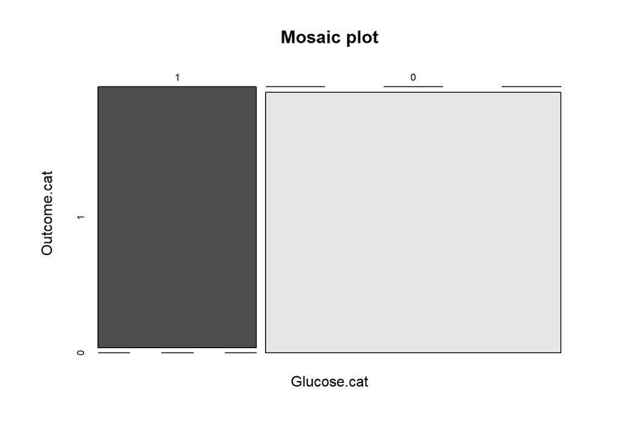

```r
#drawing mosaic plot
mosaicplot(glucose.outcome.tbl,
  main = "Mosaic plot",
  color = TRUE
)
```

```r
#fisher's exact test
test <-fisher.test(glucose.outcome.tbl)
test
```

```
##
##  Fisher's Exact Test for Count Data
##
## data:  glucose.outcome.tbl
## p-value < 0.00000000000000022
## alternative hypothesis: true odds ratio is not equal to 1
## 95 percent confidence interval:
##  8402.051      Inf
## sample estimates:
## odds ratio
##        Inf
```

#### c) Result:

```r
#retrieving p-value
test$p.value
```

```
## [1] 6.135246e-215
```

#### e) Odds Ratio:

- The odds ratio tells us how many times more positive cases can happen than negative cases. Positives represent the pairs that are the same in both variables and negatives represent the pairs that aren’t the same in both variables. So we can say positives, glucose and outcome categorical variables both become as 0 or 1. Reverse is negative.

```r
#retrieving odds ratio
test$estimate
```

```
## odds ratio
##        Inf
```

## 10. ANOVA and Tukey Test:

#### a) Aim:

- First focus on the glucose tolerance and categorical pregnancies column, so keep only 2 variables
- ANOVA used for explaining a quantitative variable based on a qualitative variable
- The question which creates our aim: Is glucose tolerance amount between the 3 category of pregnancies diffrent or not?

```r
pregancies.glucose.df <- diabetes_dataset %>% dplyr::select(Pregnancies.cat, Glucose)

summary(pregancies.glucose.df)
```

```
##  Pregnancies.cat    Glucose
##  High  :344      Min.   :  0.0
##  Normal:178      1st Qu.: 99.0
##  Low   :246      Median :117.0
##                  Mean   :120.9
##                  3rd Qu.:140.2
##                  Max.   :199.0
```

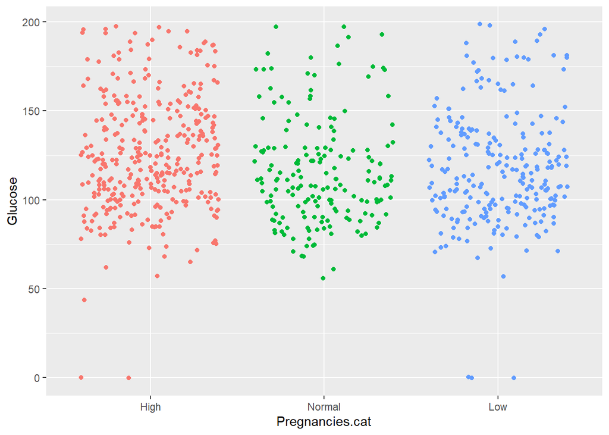

```r
#visualization for  variables
ggplot(pregancies.glucose.df) +
  aes(x = Pregnancies.cat, y = Glucose, color = Pregnancies.cat) +
  geom_jitter() +
  theme(legend.position = "none")
```

#### b) Hypothesis and level of significance:

- H0: mu(high) = mu(normal) = mu(low) -> the 3 categories are equal in terms of Glucose
- H1: at least one mean is different

#### c) Assumption Check:

- 1. All samples are independent, and collected in >2 independent categorical groups
- 2. Dependent variable is continuous
- 3. Normal distributions of each group, no major outliers
- 4. Homogeneity of variances p-value should be higher then 0.05

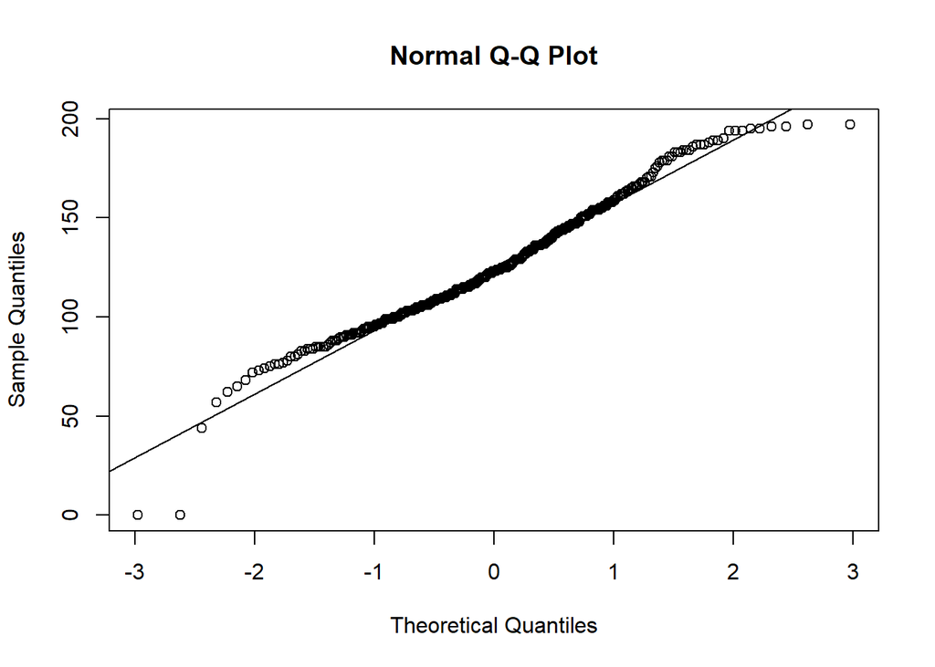

```r
#grouping
high <- subset(pregancies.glucose.df, Pregnancies.cat == "High")
normal <- subset(pregancies.glucose.df, Pregnancies.cat == "Normal")
low <- subset(pregancies.glucose.df, Pregnancies.cat == "Low")
#checking normal distributions
qqnorm(high$Glucose)
qqline(high$Glucose)
```

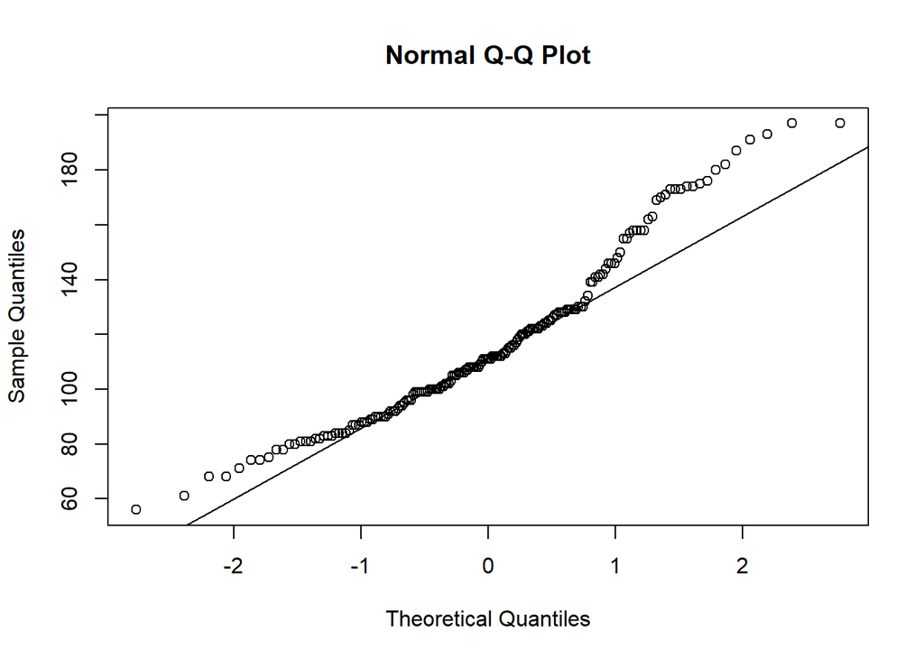

```r
qqnorm(normal$Glucose)
qqline(normal$Glucose)
```

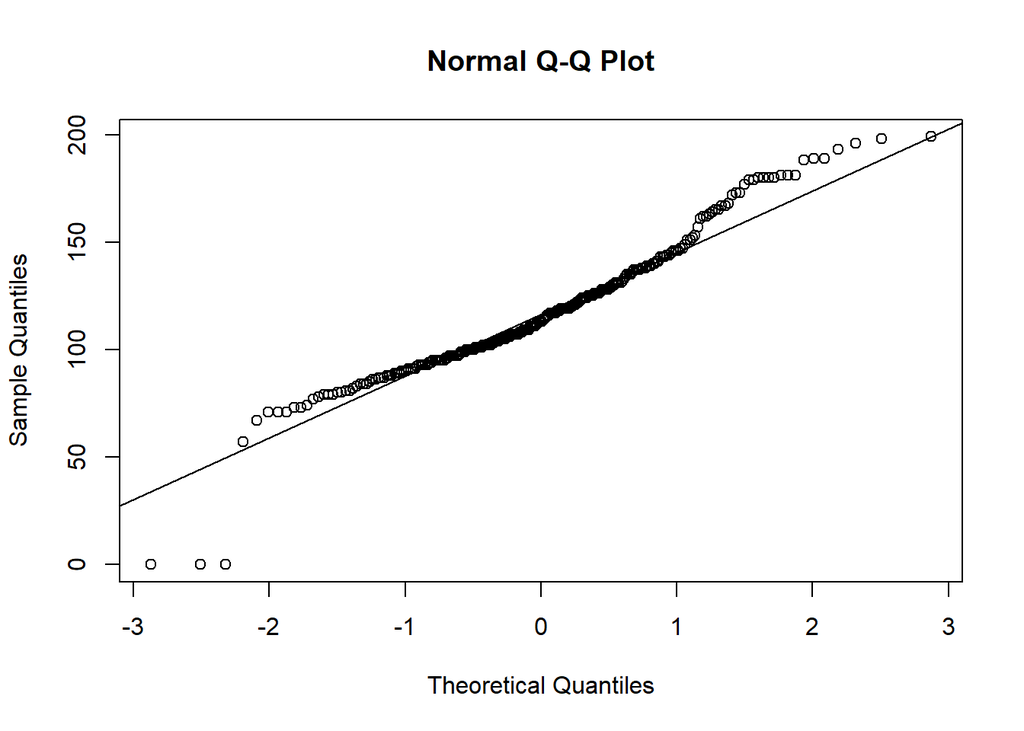

```r
qqnorm(low$Glucose)
qqline(low$Glucose)
```

```r
#homogeneity
bartlett.test(Glucose ~ Pregnancies.cat, data=diabetes_dataset )
```

```
##
##  Bartlett test of homogeneity of variances
##
## data:  Glucose by Pregnancies.cat
## Bartlett's K-squared = 1.2587, df = 2, p-value = 0.5329
```

```r
#################################
#one way ANOVA - Test if the means of the k populations are equal
model1 = lm(Glucose ~ Pregnancies.cat, data = diabetes_dataset) #lm: linear model
anova(model1)
```

```
## Analysis of Variance Table
##
## Response: Glucose
##                  Df Sum Sq Mean Sq F value    Pr(>F)
## Pregnancies.cat   2  15440  7719.9  7.6835 0.0004968 ***
## Residuals       765 768625  1004.7
## ---
## Signif. codes:  0 '***' 0.001 '**' 0.01 '*' 0.05 '.' 0.1 ' ' 1
```

```r
#Post-hoc test TukeyHSD - Test which of the categories have different means
TukeyHSD(aov(model1))
```

```
##   Tukey multiple comparisons of means
##     95% family-wise confidence level
##
## Fit: aov(formula = model1)
##
## $Pregnancies.cat
##                  diff       lwr       upr     p adj
## Normal-High -9.663444 -16.53606 -2.790826 0.0028853
## Low-High    -8.474853 -14.69006 -2.259649 0.0040551
## Low-Normal   1.188590  -6.13597  8.513151 0.9230921
```

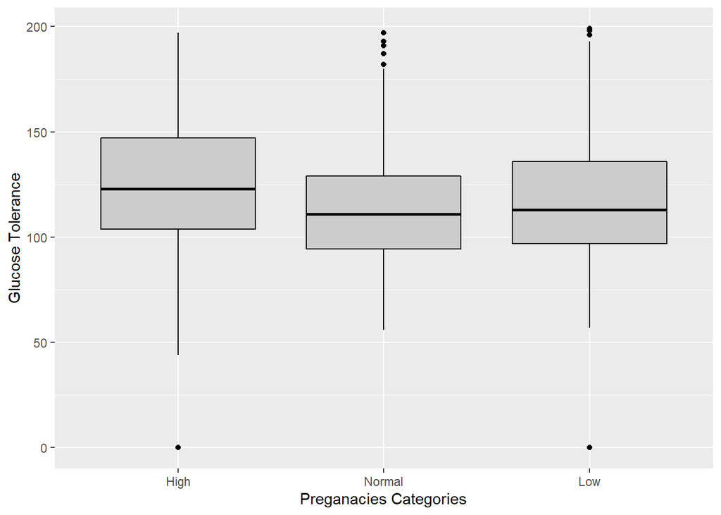

```r
##################################
#data visualization
ggplot(diabetes_dataset, aes(x=Pregnancies.cat, y=Glucose))+
  geom_boxplot(fill="grey80", colour="black")+
  scale_x_discrete()+xlab("Preganacies Categories")+
  ylab("Glucose Tolerance")
```

#### d) Result of ANOVA:

- Since, p-value = 0.5329 > 0.05 homogeneity bartlett test, we can do ANOVA.
- In ANOVA our F value = 7.6835 and p-value=0.0004968 ***. p-value is much smaller then 0.05 which means we can reject null hypothesis.

#### e) Conclusion of ANOVA:

- Rejecting indicates that there is a difference between three categories of pregnancies. However we don’t know which one is which. For this we should run post-hoc TukeyHSD.

#### f) Result of Tukey:

- When we look at the tukey test p values for every categories for pregnancy comparisons, only p-value of Low-Normal higher then 0.05 which means glucose tolerance amounts same for low and normal pregnancies. For High pregnancy comparisons, glucose tolerance amounts are different for one another.

#### g) Conclusion of Tukey:

- After doing tukey test and visualizing categorical datas we can see clearly that High pregnancy category significantly different from normal and low.

## 11. Multiple Linear Regression:

#### a) Aim:

- My aim is to find prediction of Pregnancies with multiple predictor values(columns).

#### b) Regrassion Equasion:

- With three predictor variables (x), the prediction of y is expressed by the following equation:

> y = b0 + b1*x1 + b2*x2 + b3*x3
- The “b” values are called the regression weights (or beta coefficients). They measure the association between the predictor variable and the outcome. “b_j” can be interpreted as the average effect on y of a one unit increase in “x_j”, holding all other predictors fixed.

#### c) Hypothesis and level of significance:

- I want to build a model for estimating pregnancies based multiple variables that I am going to be select with step function.
- Full model show that Multiple R-squared: 0.7481 and p-value: < 0.00000000000000022. So we can see this model is significant model.

```r
names(diabetes_dataset)
```

```
##  [1] "ID"                       "Pregnancies"
##  [3] "Glucose"                  "BloodPressure"
##  [5] "SkinThickness"            "Insulin"
##  [7] "BMI"                      "DiabetesPedigreeFunction"
##  [9] "Age"                      "Outcome"
## [11] "Pregnancies.cat"          "Outcome.cat"
## [13] "Glucose.cat"
```

```r
#first look at the full model
mlr = lm(Pregnancies ~ ., data = diabetes_dataset)
summary(mlr)
```

```
##
## Call:
## lm(formula = Pregnancies ~ ., data = diabetes_dataset)
##
## Residuals:
##     Min      1Q  Median      3Q     Max
## -4.4929 -0.7402 -0.1223  0.6607  9.5233
##
## Coefficients: (2 not defined because of singularities)
##                            Estimate Std. Error t value             Pr(>|t|)
## (Intercept)               5.5817670  0.4369603  12.774 < 0.0000000000000002 ***
## ID                        0.0002494  0.0002793   0.893              0.37220
## Glucose                  -0.0037749  0.0023746  -1.590              0.11231
## BloodPressure            -0.0014916  0.0034801  -0.429              0.66832
## SkinThickness             0.0121252  0.0047461   2.555              0.01082 *
## Insulin                  -0.0004001  0.0006384  -0.627              0.53106
## BMI                      -0.0079412  0.0091463  -0.868              0.38554
## DiabetesPedigreeFunction -0.0318118  0.1934895  -0.164              0.86945
## Age                       0.0428161  0.0064934   6.594      0.0000000000805 ***
## Outcome                   0.4646402  0.1538469   3.020              0.00261 **
## Pregnancies.catNormal    -4.0058506  0.1766716 -22.674 < 0.0000000000000002 ***
## Pregnancies.catLow       -5.8633334  0.1646960 -35.601 < 0.0000000000000002 ***
## Outcome.cat0                     NA         NA      NA                   NA
## Glucose.cat0                     NA         NA      NA                   NA
## ---
## Signif. codes:  0 '***' 0.001 '**' 0.01 '*' 0.05 '.' 0.1 ' ' 1
##
## Residual standard error: 1.703 on 756 degrees of freedom
## Multiple R-squared:  0.7481, Adjusted R-squared:  0.7444
## F-statistic: 204.1 on 11 and 756 DF,  p-value: < 0.00000000000000022
```

```r
#FOR SMALLER MODEL
#step function
model.final = step(mlr) #looking for both directions
```

```
## Start:  AIC=830.06
## Pregnancies ~ ID + Glucose + BloodPressure + SkinThickness +
##     Insulin + BMI + DiabetesPedigreeFunction + Age + Outcome +
##     Pregnancies.cat + Outcome.cat + Glucose.cat
##
##
## Step:  AIC=830.06
## Pregnancies ~ ID + Glucose + BloodPressure + SkinThickness +
##     Insulin + BMI + DiabetesPedigreeFunction + Age + Outcome +
##     Pregnancies.cat + Outcome.cat
##
##
## Step:  AIC=830.06
## Pregnancies ~ ID + Glucose + BloodPressure + SkinThickness +
##     Insulin + BMI + DiabetesPedigreeFunction + Age + Outcome +
##     Pregnancies.cat
##
##                            Df Sum of Sq    RSS     AIC
## - DiabetesPedigreeFunction  1       0.1 2193.8  828.09
## - BloodPressure             1       0.5 2194.2  828.25
## - Insulin                   1       1.1 2194.9  828.46
## - BMI                       1       2.2 2195.9  828.83
## - ID                        1       2.3 2196.0  828.87
## <none>                                  2193.7  830.06
## - Glucose                   1       7.3 2201.0  830.63
## - SkinThickness             1      18.9 2212.7  834.66
## - Outcome                   1      26.5 2220.2  837.27
## - Age                       1     126.2 2319.9  871.01
## - Pregnancies.cat           2    3754.1 5947.9 1592.09
##
## Step:  AIC=828.09
## Pregnancies ~ ID + Glucose + BloodPressure + SkinThickness +
##     Insulin + BMI + Age + Outcome + Pregnancies.cat
##
##                   Df Sum of Sq    RSS     AIC
## - BloodPressure    1       0.5 2194.3  826.27
## - Insulin          1       1.2 2195.0  826.51
## - BMI              1       2.2 2196.0  826.87
## - ID               1       2.4 2196.1  826.92
## <none>                         2193.8  828.09
```

[output cut: 43 more lines]

```
## - SkinThickness    1      17.9 2215.7  827.74
## - Outcome          1      27.2 2225.1  830.97
## - Age              1     131.6 2329.5  866.19
## - Pregnancies.cat  2    3810.7 6008.5 1591.89
##
## Step:  AIC=822.43
## Pregnancies ~ Glucose + SkinThickness + Age + Outcome + Pregnancies.cat
##
##                   Df Sum of Sq    RSS     AIC
## <none>                         2200.5  822.43
## - Glucose          1      12.1 2212.5  824.63
## - SkinThickness    1      15.3 2215.7  825.74
## - Outcome          1      24.9 2225.4  829.06
## - Age              1     132.1 2332.6  865.21
## - Pregnancies.cat  2    3810.2 6010.6 1590.16
```

### d) Find the Best Model:

```r
summary(model.final)
```

```
##
## Call:
## lm(formula = Pregnancies ~ Glucose + SkinThickness + Age + Outcome +
##     Pregnancies.cat, data = diabetes_dataset)
##
## Residuals:
##     Min      1Q  Median      3Q     Max
## -4.3697 -0.7460 -0.1327  0.6470  9.4892
##
## Coefficients:
##                        Estimate Std. Error t value             Pr(>|t|)
## (Intercept)            5.430312   0.341826  15.886 < 0.0000000000000002 ***
## Glucose               -0.004516   0.002210  -2.043              0.04140 *
## SkinThickness          0.009016   0.003923   2.298              0.02183 *
## Age                    0.042825   0.006335   6.760      0.0000000000274 ***
## Outcome                0.434151   0.147980   2.934              0.00345 **
## Pregnancies.catNormal -3.983142   0.174473 -22.830 < 0.0000000000000002 ***
## Pregnancies.catLow    -5.857905   0.163126 -35.910 < 0.0000000000000002 ***
## ---
## Signif. codes:  0 '***' 0.001 '**' 0.01 '*' 0.05 '.' 0.1 ' ' 1
##
## Residual standard error: 1.7 on 761 degrees of freedom
## Multiple R-squared:  0.7473, Adjusted R-squared:  0.7453
## F-statistic: 375.1 on 6 and 761 DF,  p-value: < 0.00000000000000022
```

- My AIC value after applied step function is AIC=822.43 . The smaller AIC value is better. Finally in our model we use;

> Pregnancies ~ Glucose + SkinThickness + Age + Outcome + Pregnancies.cat

### e) Assumption Check:

1. Using step predicted model

```r
mlr1 = lm(formula = Pregnancies ~ Glucose + SkinThickness + Age + Outcome +
    Pregnancies.cat, data = diabetes_dataset)
summary(mlr1)
```

```
##
## Call:
## lm(formula = Pregnancies ~ Glucose + SkinThickness + Age + Outcome +
##     Pregnancies.cat, data = diabetes_dataset)
##
## Residuals:
##     Min      1Q  Median      3Q     Max
## -4.3697 -0.7460 -0.1327  0.6470  9.4892
##
## Coefficients:
##                        Estimate Std. Error t value             Pr(>|t|)
## (Intercept)            5.430312   0.341826  15.886 < 0.0000000000000002 ***
## Glucose               -0.004516   0.002210  -2.043              0.04140 *
## SkinThickness          0.009016   0.003923   2.298              0.02183 *
## Age                    0.042825   0.006335   6.760      0.0000000000274 ***
## Outcome                0.434151   0.147980   2.934              0.00345 **
## Pregnancies.catNormal -3.983142   0.174473 -22.830 < 0.0000000000000002 ***
## Pregnancies.catLow    -5.857905   0.163126 -35.910 < 0.0000000000000002 ***
## ---
## Signif. codes:  0 '***' 0.001 '**' 0.01 '*' 0.05 '.' 0.1 ' ' 1
##
## Residual standard error: 1.7 on 761 degrees of freedom
## Multiple R-squared:  0.7473, Adjusted R-squared:  0.7453
## F-statistic: 375.1 on 6 and 761 DF,  p-value: < 0.00000000000000022
```

2. The independent variables are not highly correlated with each other(scatter plotting for linearity)

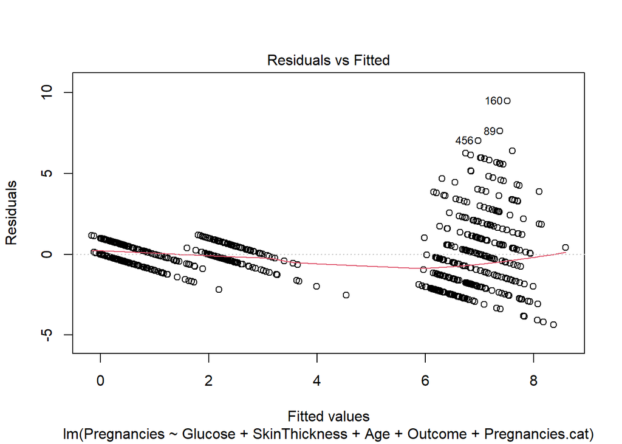

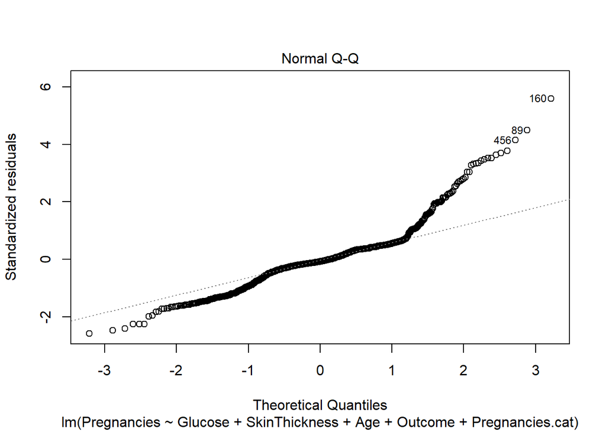

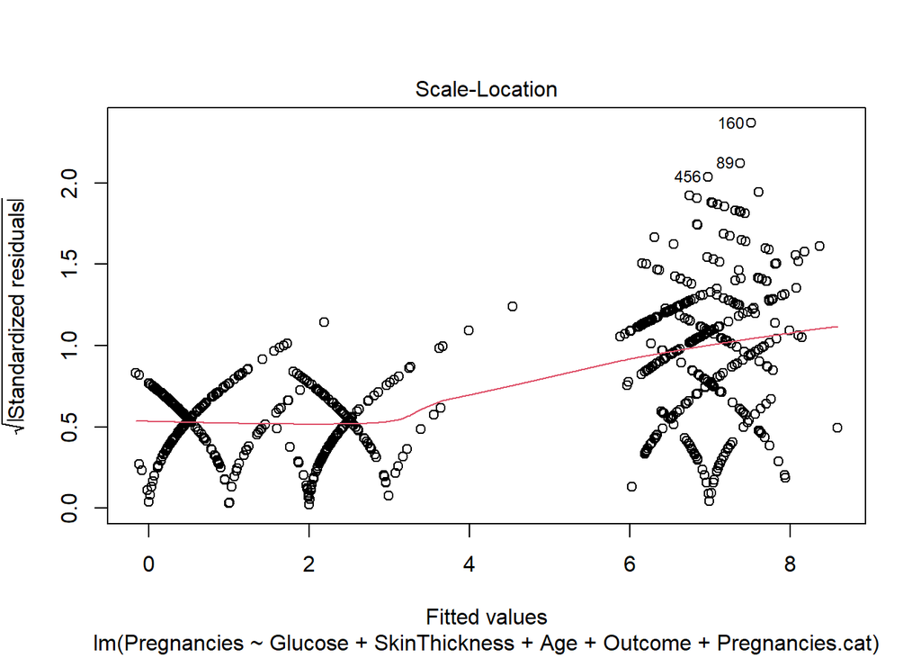

```r
plot(mlr1)
```

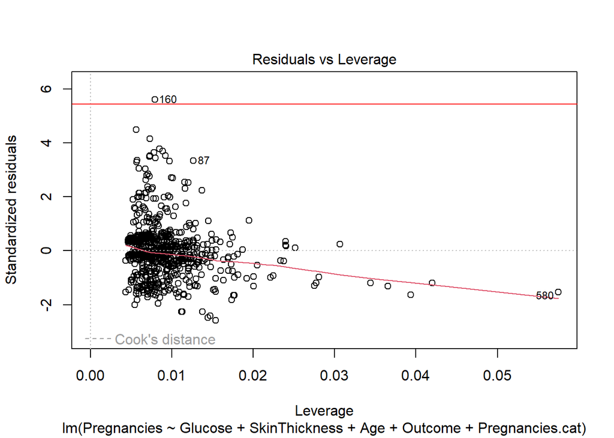

```r
abline(mlr1, col="red")
```

### f) Result:

- In our example, it can be seen that p-value of the F-statistic is < 2.2e-16, which is highly significant. This means that, at least, one of the predictor variables is significantly related to the outcome variable.
- To see which predictor variables are significant, you can examine the coefficients table, which shows the estimate of regression beta coefficients and the associated t-statitic p-values:

```r
sum_coef<-summary(mlr1)$coefficient
sum_coef
```

```
##                           Estimate  Std. Error    t value      Pr(>|t|)
## (Intercept)            5.430312466 0.341825707  15.886203  2.711170e-49
## Glucose               -0.004515725 0.002210325  -2.043014  4.139504e-02
## SkinThickness          0.009016267 0.003923415   2.298066  2.182837e-02
## Age                    0.042824964 0.006334811   6.760259  2.742742e-11
## Outcome                0.434150819 0.147979985   2.933848  3.448520e-03
## Pregnancies.catNormal -3.983141640 0.174473208 -22.829532  2.799338e-88
## Pregnancies.catLow    -5.857905438 0.163126437 -35.910215 5.783549e-166
```

```r
mlr1.1  <- lm(formula = Pregnancies ~ SkinThickness + Age + Outcome, data = diabetes_dataset)
summary(mlr1.1)
```

```
##
## Call:
## lm(formula = Pregnancies ~ SkinThickness + Age + Outcome, data = diabetes_dataset)
##
## Residuals:
##     Min      1Q  Median      3Q     Max
## -8.7267 -1.7677 -0.2359  1.6099 10.7841
##
## Coefficients:
##                Estimate Std. Error t value             Pr(>|t|)
## (Intercept)   -1.194686   0.346215  -3.451              0.00059 ***
## SkinThickness -0.006404   0.006443  -0.994              0.32057
## Age            0.148080   0.008974  16.501 < 0.0000000000000002 ***
## Outcome        0.713392   0.220449   3.236              0.00126 **
## ---
## Signif. codes:  0 '***' 0.001 '**' 0.01 '*' 0.05 '.' 0.1 ' ' 1
##
## Residual standard error: 2.812 on 764 degrees of freedom
## Multiple R-squared:  0.3062, Adjusted R-squared:  0.3035
## F-statistic: 112.4 on 3 and 764 DF,  p-value: < 0.00000000000000022
```

```r
#conf.int extraction
confint(mlr1.1)
```

```
##                    2.5 %      97.5 %
## (Intercept)   -1.8743308 -0.51504103
## SkinThickness -0.0190525  0.00624425
## Age            0.1304634  0.16569673
## Outcome        0.2806357  1.14614907
```

### g) Conclusion:

- Finally, our mlr1.1 equation can be written as follow: Pregnancies = -1.19 + 0.148*Age + 0.713*Outcome + -0.006*SkinThickness

### h) Prediction:

- Main assumption is to checking how significant this step predicted model is. I checked that with adding different variables.

```r
mlr1 = lm(formula = Pregnancies ~ Glucose + SkinThickness + Age + Outcome +
    Pregnancies.cat, data = diabetes_dataset)
summary(mlr1)
```

```
##
## Call:
## lm(formula = Pregnancies ~ Glucose + SkinThickness + Age + Outcome +
##     Pregnancies.cat, data = diabetes_dataset)
##
## Residuals:
##     Min      1Q  Median      3Q     Max
## -4.3697 -0.7460 -0.1327  0.6470  9.4892
##
## Coefficients:
##                        Estimate Std. Error t value             Pr(>|t|)
## (Intercept)            5.430312   0.341826  15.886 < 0.0000000000000002 ***
## Glucose               -0.004516   0.002210  -2.043              0.04140 *
## SkinThickness          0.009016   0.003923   2.298              0.02183 *
## Age                    0.042825   0.006335   6.760      0.0000000000274 ***
## Outcome                0.434151   0.147980   2.934              0.00345 **
## Pregnancies.catNormal -3.983142   0.174473 -22.830 < 0.0000000000000002 ***
## Pregnancies.catLow    -5.857905   0.163126 -35.910 < 0.0000000000000002 ***
## ---
## Signif. codes:  0 '***' 0.001 '**' 0.01 '*' 0.05 '.' 0.1 ' ' 1
##
## Residual standard error: 1.7 on 761 degrees of freedom
## Multiple R-squared:  0.7473, Adjusted R-squared:  0.7453
## F-statistic: 375.1 on 6 and 761 DF,  p-value: < 0.00000000000000022
```

```r
mlr2 = lm(formula = Pregnancies ~ Glucose + SkinThickness + Age + Outcome +
    Pregnancies.cat+BMI, data = diabetes_dataset)
summary(mlr2)
```

```
##
## Call:
## lm(formula = Pregnancies ~ Glucose + SkinThickness + Age + Outcome +
##     Pregnancies.cat + BMI, data = diabetes_dataset)
##
## Residuals:
##     Min      1Q  Median      3Q     Max
## -4.3855 -0.7519 -0.1382  0.6478  9.5035
##
## Coefficients:
##                        Estimate Std. Error t value             Pr(>|t|)
## (Intercept)            5.639222   0.406588  13.870 < 0.0000000000000002 ***
## Glucose               -0.004313   0.002221  -1.942              0.05252 .
## SkinThickness          0.010560   0.004247   2.486              0.01313 *
## Age                    0.042746   0.006336   6.747        0.00000000003 ***
## Outcome                0.464423   0.151388   3.068              0.00223 **
## Pregnancies.catNormal -3.995276   0.174952 -22.836 < 0.0000000000000002 ***
## Pregnancies.catLow    -5.856208   0.163147 -35.895 < 0.0000000000000002 ***
## BMI                   -0.008466   0.008921  -0.949              0.34289
## ---
## Signif. codes:  0 '***' 0.001 '**' 0.01 '*' 0.05 '.' 0.1 ' ' 1
##
## Residual standard error: 1.701 on 760 degrees of freedom
## Multiple R-squared:  0.7476, Adjusted R-squared:  0.7453
## F-statistic: 321.6 on 7 and 760 DF,  p-value: < 0.00000000000000022
```

## 12. Generalized Linear Model

```r
library(sjPlot)
library(lme4)
m = glm(Outcome ~ Age + DiabetesPedigreeFunction, family = binomial, data = diabetes_dataset)
tab_model(m)
```

|  | Outcome |  |  |
| --- | --- | --- | --- |
| Predictors | Odds Ratios | CI | p |
| (Intercept) | 0.08 | 0.04 – 0.13 | **<0.001** |
| Age | 1.04 | 1.03 – 1.06 | **<0.001** |
| DiabetesPedigreeFunction | 2.93 | 1.86 – 4.70 | **<0.001** |
| Observations | 768 |  |  |
| R<sup>2</sup> Tjur | 0.082 |  |  |

- In the current model the Odds Ratios for DiabetesPedigreeFunction (2.93) indicate that for every unit increase of DiabetesPedigreeFunction, the odds are multiplied by 2.93.
- If the value is between 0 and 1, the effect is negative, because the odds decrease. If the value is higher than 1, the effect is positive.
- To evaluate model fit, you can compare models using the anova function. For example, here we first make a base model that does not contain any independent variables, and also make a second model with the BMI information included. We then compare how the model fit changes.

```r
m_base = glm(Outcome ~ 1, family = binomial, data = diabetes_dataset)
m1 = glm(Outcome ~ Age + DiabetesPedigreeFunction, family = binomial, data = diabetes_dataset)
m2 = glm(Outcome ~ Age + DiabetesPedigreeFunction + BMI, family = binomial, data = diabetes_dataset)
anova(m_base, m1,m2, test="Chisq")
```

```
## Analysis of Deviance Table
##
## Model 1: Outcome ~ 1
## Model 2: Outcome ~ Age + DiabetesPedigreeFunction
## Model 3: Outcome ~ Age + DiabetesPedigreeFunction + BMI
##   Resid. Df Resid. Dev Df Deviance              Pr(>Chi)
## 1       767     993.48
## 2       765     929.10  2   64.380 0.0000000000000104714 ***
## 3       764     862.01  1   67.097 0.0000000000000002585 ***
## ---
## Signif. codes:  0 '***' 0.001 '**' 0.01 '*' 0.05 '.' 0.1 ' ' 1
```

```r
#table
tab_model(m1,m2)
```

|  | Outcome |  |  | Outcome |  |  |
| --- | --- | --- | --- | --- | --- | --- |
| Predictors | Odds Ratios | CI | p | Odds Ratios | CI | p |
| (Intercept) | 0.08 | 0.04 – 0.13 | **<0.001** | 0.00 | 0.00 – 0.01 | **<0.001** |
| Age | 1.04 | 1.03 – 1.06 | **<0.001** | 1.05 | 1.03 – 1.06 | **<0.001** |
| DiabetesPedigreeFunction | 2.93 | 1.86 – 4.70 | **<0.001** | 2.52 | 1.54 – 4.19 | **<0.001** |
| BMI |  |  |  | 1.10 | 1.07 – 1.13 | **<0.001** |
| Observations | 768 |  |  | 768 |  |  |
| R<sup>2</sup> Tjur | 0.082 |  |  | 0.161 |  |  |

- . Finally, to illustrate how fitting a glm is different from using a regular lm, we can plot the regression line for the DiabetesPedigreeFunction. For this we can use the amazing and extremely versatile plot_model function from the sjPlot package. Here we plot the prediction of the model for different values of DiabetesPedigreeFunction.

```
## Data were 'prettified'. Consider using `terms="DiabetesPedigreeFunction [all]"` to get smooth plots.
```

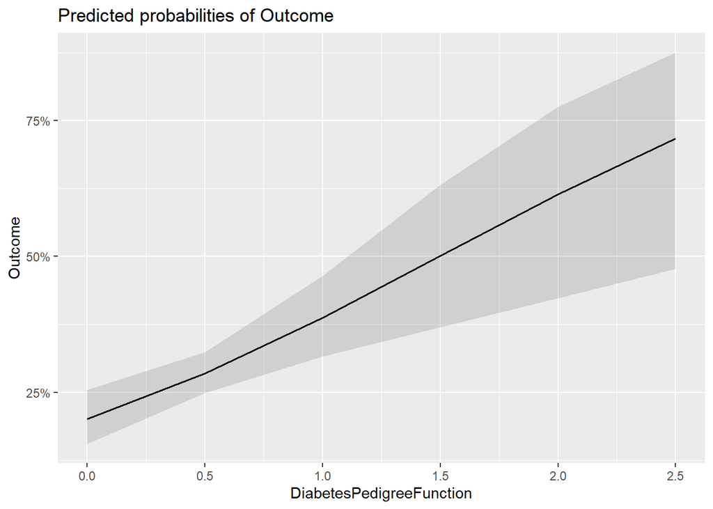

```r
plot_model(m2, type = 'pred', terms = 'DiabetesPedigreeFunction')
```

- You can also produce this plot for all independent variables in a grid.

```r
p = plot_model(m2, type = 'pred')     ## creates a list of plots
```

```
## Data were 'prettified'. Consider using `terms="Age [all]"` to get smooth plots.
```

```
## Data were 'prettified'. Consider using `terms="DiabetesPedigreeFunction [all]"` to get smooth plots.
```

```
## Data were 'prettified'. Consider using `terms="BMI [all]"` to get smooth plots.
```

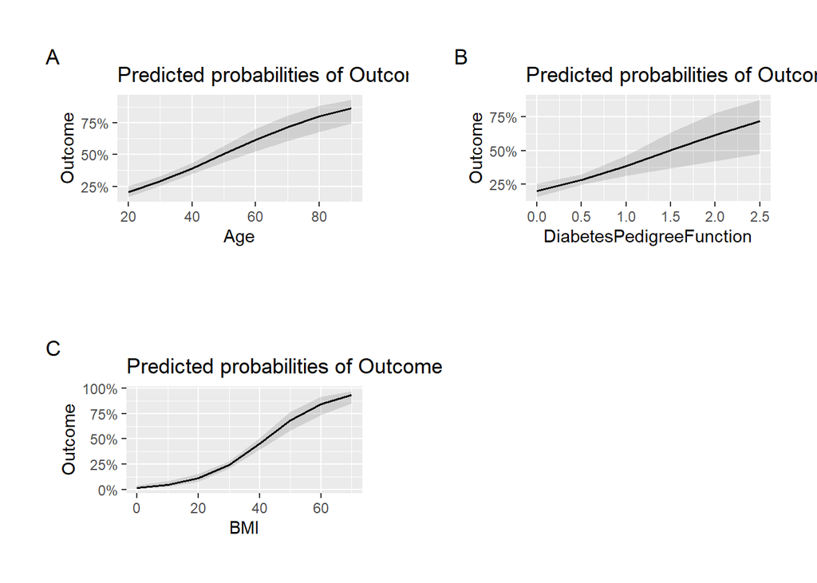

```r
plot_grid(p)
```